# Classification Model (Penguins)

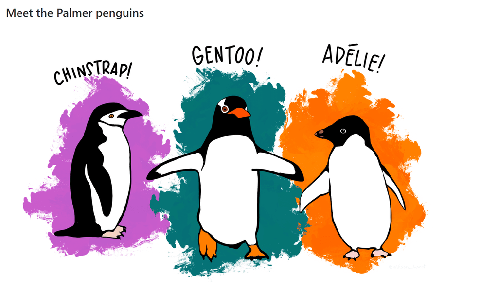

**Classification model for PenguinsWithoutMissingValues**

- Use a decision tree to build a classifier for the Gender
- do a data preprocessing, e.g.: delete unnecessary columns, encode categorical data
- use a random 80%/20% training/test set
- for the training:
  - do a 10-fold cross validation
  - check its accuracy and choose the best model for predicting the test set
- predict the Gender of the test data
  - check accuracy and the confusion matrix

**Predict the missing Gender labels of the dataframe PenguinsWithoutGender**

- do an appropriate data preprocessing, e.g.: delete unnecessary columns, encode categorical data
- predict the Gender of the observations

**Helpful Links:**

- https://topepo.github.io/caret/
- https://rpubs.com/maelillien/penguins-classification
- https://stats.stackexchange.com/questions/82162/cohens-kappa-in-plain-english

```r
# Delete all variables
rm( list = ls() )

# Import libraries
library(caret)
```

# Classification model for PenguinsWithoutMissingValues$Gender

Import the dataframes PenguinsWithoutMissingValues and PenguinsWithoutGender from the csv files.

Use therefore the function read.csv() or read.csv2() depending on your system’s language (for a correct “.” and “,” interpretation)

## Preprocessing

- delete column IndividualID
- encode Species and Island

## Build and evaluate a classifier

### Use the classifier to predict the test data

Use and evaluate the classifier to predict the Gender

# Predict the Gender of the dataframe PenguinsWithoutGender

Use the classifier to predict the Gender in the dataframe PenguinsWithoutGender

## Preprocessing

- delete column IndividualID
- encode Species and Island

## Predict the missing Gender

In this case, we cannot evaluate the prediction accuracy at all.